# Regex in R

14 January 2019

## Regular Expressions

[figure not shown]

- A 'language' to represent text patterns - concept invented in the 1950's
- Bound by a set of rules (syntax); a set of special characters used to denote patterns
- Multi-platform: available (natively or through libraries) in many languages and tools (R, Python, Java, sed, awk)
- Use cases:
  - read files with a specific naming pattern, e.g. 20190114_Mon_P1_W08_R2.csv, 20190114_Mon_P10_W01_R3.csv
  - search for text patterns
  - replace text patterns

## The basics

- Character classes `[]`
  - any character: `.`
  - alphabet: `[A-Z]` or `[:upper:]`, `[a-z]` or `[:lower:]`, `[A-Za-z]` or `[:alpha:]`
  - numeric: `[0-9]` or `[:digit:]` or `\d`
  - alphanumeric: `[A-Za-z0-9]` or `[:alnum:]`
  - whitespace (space, tab, linebreak): `\s`
- quantifiers:
  - one or more (of the preceding character): `+`
  - zero or more: `*`
  - zero or one: `?`
  - specified number: `{m,}`, `{m,n}`

## The basics

- anchors:
  - start: `^` (except in the context of `[^ ]`, where it is negation)
  - end: `$`
- capture groups:
  - extract groups: `()`
  - refer to captured groups: `\1`, `\2`, etc.
- metacharacters: `. \ | ( ) [ { ^ $ * + ? ,`

## Examples

- https://regexr.com/
- in the string "the cat in the hat has a bat":
  - `[ch]at` matches `cat` and `hat`
  - `.at` matches `cat`, `hat` and `bat`
  - `.{2}` matches `in`
  - `[:alpha:]{1,2}` matches `in` and `a`
  - `.\s.` matches `e c`, `t i`, `n t`, `e h`, `t h`, `s a`, `a b`

## Strings in R

- Strings ("character" class) are represented in R using " or '
- But what about special characters like newlines and tabs? They are represented as escape sequences.`print` prints the escape sequence, whereas `cat` processes them.

```r
string = "First\tline\nSecond\tline"
print(string)
```

```
## [1] "First\tline\nSecond\tline"
```

```r
cat(string)
```

```
## First    line
## Second   line
```

## Strings in R

- What if the string contains an invalid escape character?

```r
regex_string = ".\s."
```

```
## Error: '\s' is an unrecognized escape in character string starting "".\s"
```

- Regular expressions are represented as strings in R. But strings are processed first for escape characters. Unrecognised escape characters in strings throw an error, before even reaching the regex parser.
- Double backslahes needed for regex escape sequences

```r
regex_string = ".\\s."
string = "the cat in the hat has a bat"
regexpr(regex_string, string)
```

[figure not shown]

## Base R functions that use regex

- `grep()`
- `grepl()`
- `regexpr()`
- `gregexpr()`
- `sub()`
- `gsub()`
- `strsplit()`
- `list.files()`

## Stringr functions

As with other Tidyverse functions, Stringr functions take the *text* as the first argument and the pattern as the second argument

- `str_locate()` - like `regexpr()`, but returns an integer matrix
- `str_detect()` - like `grepl()`
- `str_split()` - like `strsplit()`
- `str_extract()` - like `match = regexpr(pattern, string); substring(string, match, match + attr(match, "match.length") - 1)`

## Test drive

```r
library(babynames)
library(stringr)
library(dplyr)
```

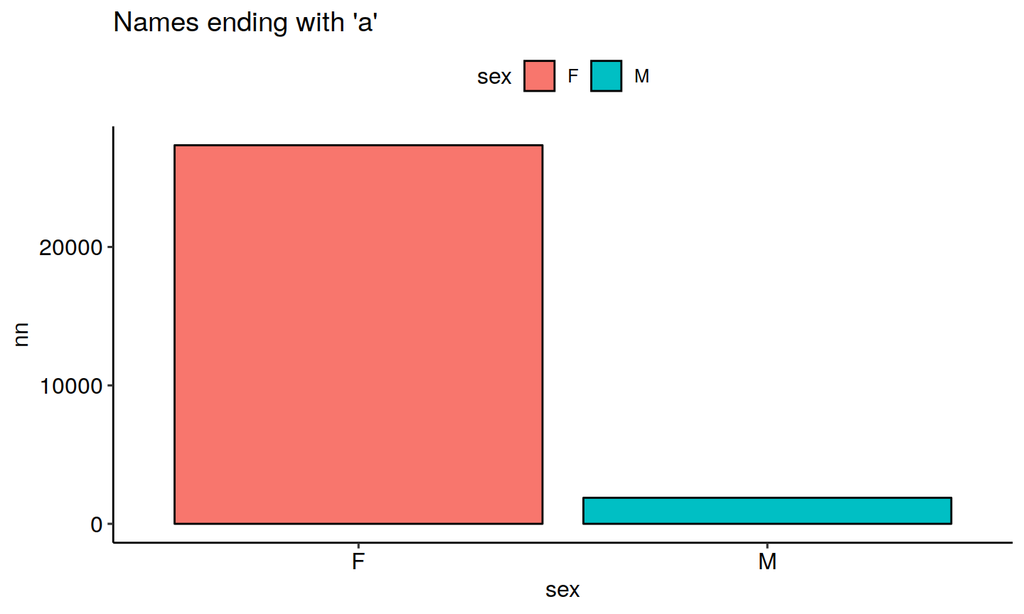

```r
library(ggplot2)
library(ggpubr)
babynames %>%
  group_by(name, sex) %>%
  summarise(n = sum(n)) -> sum_babynames

sum_babynames %>%
  filter(str_detect(name, "a$")) %>%
  group_by(sex) %>%
  count() %>%
  ggplot(aes(x = sex, y = nn, fill = sex)) +
    geom_col(colour = "black") +
    labs(title = "Names ending with 'a'") +
    theme_pubr(margin = TRUE)
```

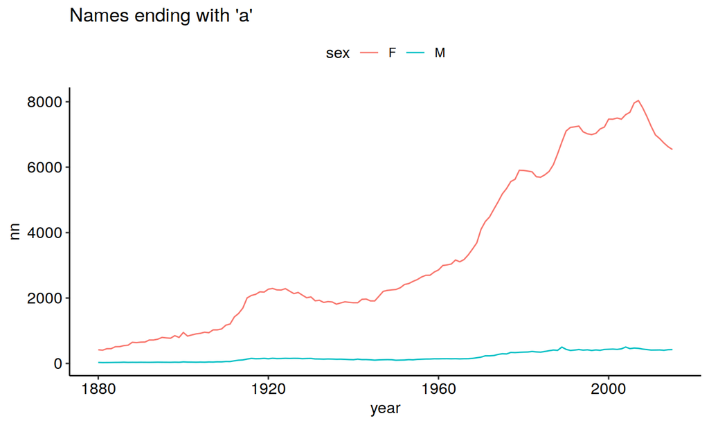

```r
babynames %>%
  filter(str_detect(name, "a$")) %>%
  group_by(sex, year) %>%
  count() %>%
  ggplot(aes(x = year, y = nn, colour = sex)) +
    geom_line() +
    labs(title = "Names ending with 'a'") +
    theme_pubr(margin = TRUE)
```

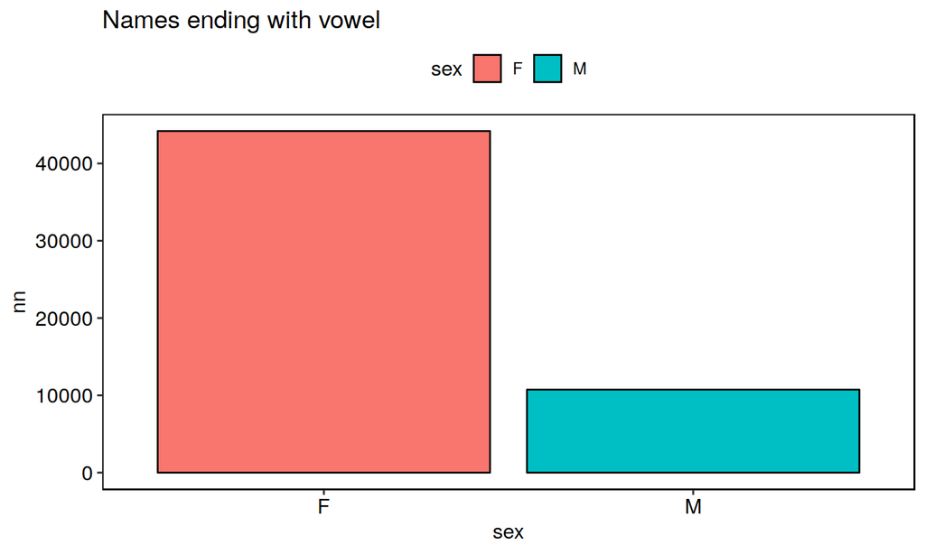

```r
sum_babynames %>%
  filter(str_detect(name, "[aeiou]$")) %>%
  group_by(sex) %>%
  count() %>%
  ggplot(aes(x = sex, y = nn, fill = sex)) +
    geom_col(colour = "black") +
    labs(title = "Names ending with vowel") +
    theme_pubr(border = TRUE)
```

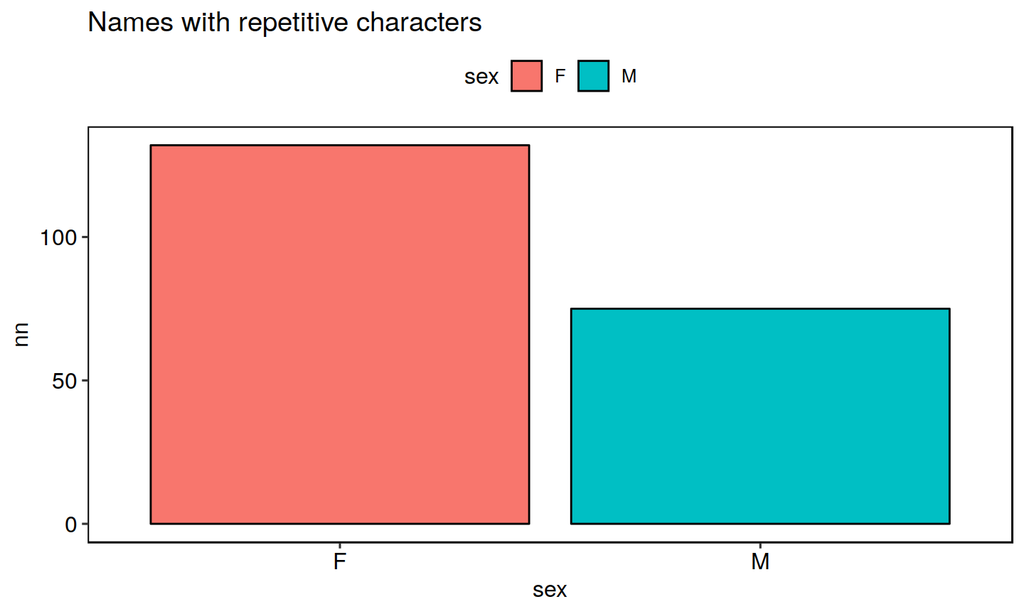

```r
sum_babynames %>%
  filter(str_detect(name, "(.{2})\\1")) %>%
  group_by(sex) %>%
  #filter(sex == "M") %>%
  count() %>%
  #print()
  ggplot(aes(x = sex, y = nn, fill = sex)) +
    geom_col(colour = "black") +
    labs(title = "Names with repetitive characters") +
    theme_pubr(border = TRUE)
```

```r
sum_babynames %>%
  filter(str_detect(name, "[HhZz]ero")) %>%
  group_by(sex) %>%
  #filter(sex == "M") %>%
  #count() %>%
  print()
```

```
## # A tibble: 35 x 3
## # Groups:   sex [2]
##    name     sex       n
##    <chr>    <chr> <int>
##  1 Acheron  M        39
##  2 Cherod   M         6
##  3 Cherokee F      2337
##  4 Cherokee M       332
##  5 Cherol   F        17
##  6 Cherolyn F        60
##  7 Cheron   F       635
##  8 Cheron   M        99
##  9 Cheronda F       164
## 10 Cherone  F         7
## # ... with 25 more rows
```

```r
  #ggplot(aes(x = sex, y = nn, fill = sex)) +
    #geom_col(colour = "black") +
    #labs(title = "Names with repetitive characters")
    #theme_pubr(border = TRUE)
```

## Commenting within a regex